# Crash course - Decoding Road accidents in the USA

## Generalised Additive Model

#### Vitalia Vedenikova took the lead on the Generalised Additive Model section

### Generalized Additive Model Fit

For our GAM, we decide to add back the continuous variables we had examined in the exploratory visual analysis to see if we had missed a polynomial predictor. We do so using smoothers.

We find that contrary to the linear model, the GAM model identifies the temperature and the cities’ populations as significant predictors while there is no strong evidence that the precipitation amounts’ effect is different from zero. The edf value of the temperature is 6.3, meaning that there is a non-linear effect. Similarity, the cities’ populations edf is of 8.5, meaning that there is a non-linear effect there too.

Overall, the model is barely better than the linear model, with only 9% of the variance of the response variable explained by its relation to the explanatory variable.

```r
#GAM model fit
gam.accidents <-gam(log(duration)~ severity + state + month + street + severity*street + s(temp_c) + s(presip_mm) + s(cities_population), data=d.accidents)

#Approximative significance of smooth terms
gam.summary <- summary(gam.accidents)
gam.summary$s.table
```

```
##                           edf   Ref.df         F   p-value
## s(temp_c)            6.348075 7.332586  9.522440 0.0000000
## s(presip_mm)         1.000000 1.000000  1.113267 0.2913756
## s(cities_population) 8.515673 8.892562 29.620843 0.0000000
```

```r
gam.summary$r.sq #r-squared value
```

```
## [1] 0.09074888
```

As we already know from the linear model QQ-Plots, our data is very skewed and does not fulfill normality assumptions. This therefore explains why with a GAM we also have a very poorly fitting model.  
Looking closer at the estimated smooth functions of the variables with strong evidence of significance, we cannot really see visual evidence of polynomials, so perhaps our model is also overfitted.

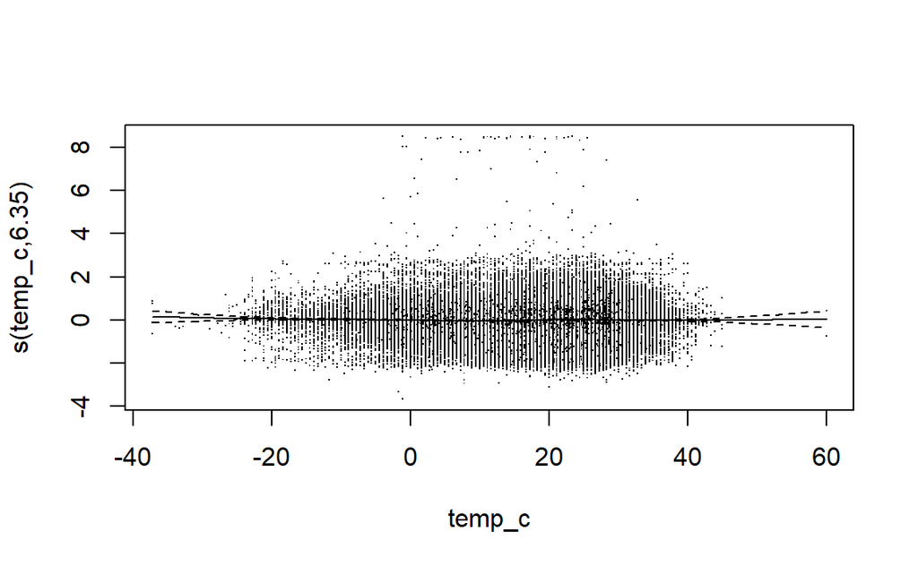

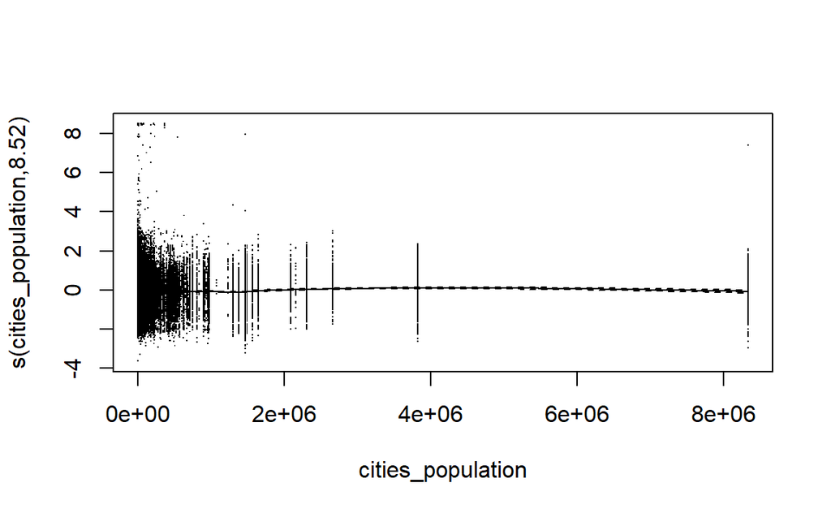

Once we run gam.check(), we see that the k-index is very close to one, so there is no missed pattern left in the residuals. We cannot adjust the k to optimize our model further as this suggests there are no significant patterns in the residuals and there are enough basis functions for all smoother terms. The Response vs Fitted Values plot also clearly suggests that the model is a very bad fit since there is no 1 to 1 line present.

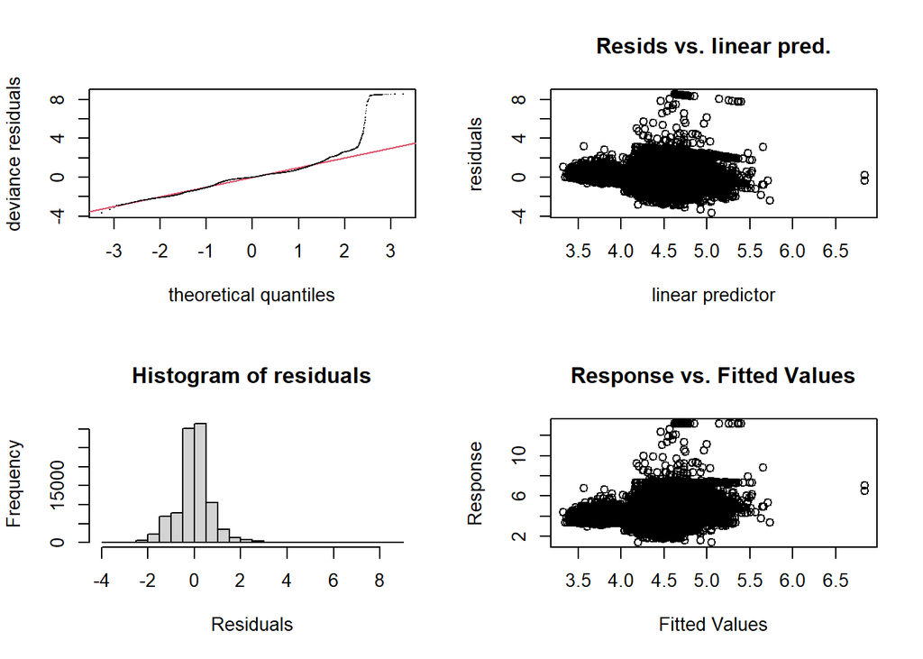

```
##
## Method: GCV   Optimizer: magic
## Smoothing parameter selection converged after 12 iterations.
## The RMS GCV score gradient at convergence was 1.239408e-07 .
## The Hessian was positive definite.
## Model rank =  155 / 158
##
## Basis dimension (k) checking results. Low p-value (k-index<1) may
## indicate that k is too low, especially if edf is close to k'.
##
##                        k'  edf k-index p-value
## s(temp_c)            9.00 6.35    0.99    0.28
## s(presip_mm)         9.00 1.00    0.99    0.26
## s(cities_population) 9.00 8.52    0.99    0.17
```

In conclusion, there is poor evidence that the GAM model is a good fit for modelling the duration of car accidents. It does however suggest that there might be a non-linear effect from cities’ populations and temperature which we might have overlooked by only using the linear model.

## Number of accidents per state

As we previously noticed, US States were a statistically significant variable in predicting the duration of accidents. It is also easy to observe that the number of accidents varies a lot per State. In this section of our work, we strive to understand why this is the case to be able to address the causes and provide suggestions on how to reduce the amount of accidents in the future.

## GLM Models

#### Perez Olusese took the lead on the Poisson and Binomial models

## GLM - Poisson

The Generalized Linear Model (GLM) with a Poisson distribution is a powerful tool for count data analysis, ideal for scenarios where the response variable represents non-negative integer counts.The count data in our dataset is the accident count per state. Data compatibility will be considered for this analysis to ensure the independent variables are suitable for this analysis. state, city, and county are not appropriate as independent variables in this Poisson model as they are categorical variables with very many levels.

### Exploratory data analysis

The independent variables that will look at exploring for this are severity, weather, month and time interval. We will therefore start the exploratory data analysis with these variables.

### Severity

The boxplot and barplot helps visualize the distribution of accident counts across different severity levels. This visualization can reveal whether higher severity levels are associated with higher or accident counts.

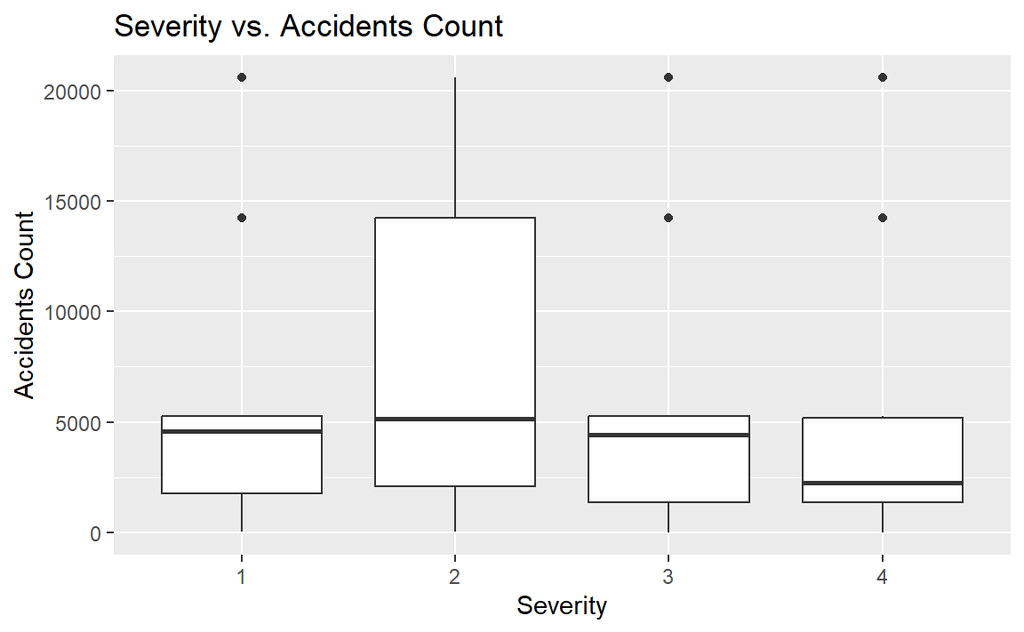

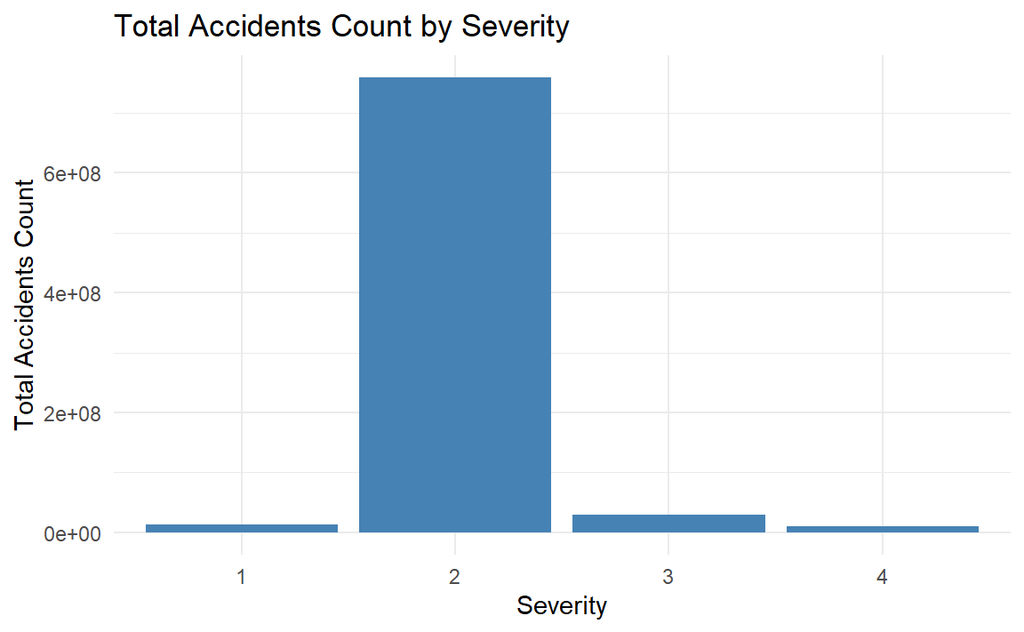

### Weather Conditions

Weather conditions can be considered as a factor that could affect the number of accidents count per state. To justify this assumption we will also do an Explanatory data analysis so as to see if of weather conditions on the accident counts per state.

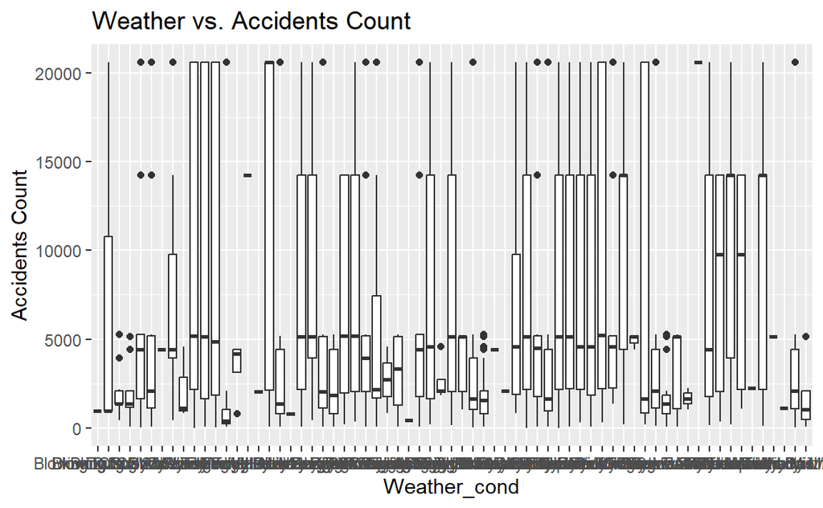

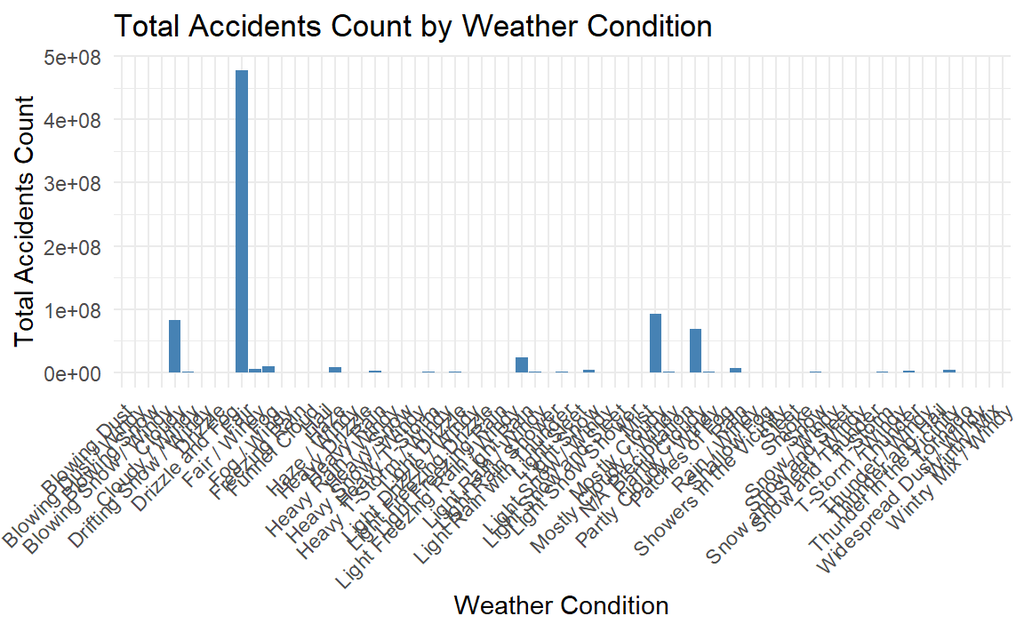

There are some weather conditions that show some evidence that accidents counts increase during those conditions.we shall therefore use variable in our analysis.

### Month

We are going to consider months in our study so as to establish whether the month actually has an effect on the accident count per state.

From the Bar plot we can see the variation of accident counts in every month with the highest accidents appearing in month 4.

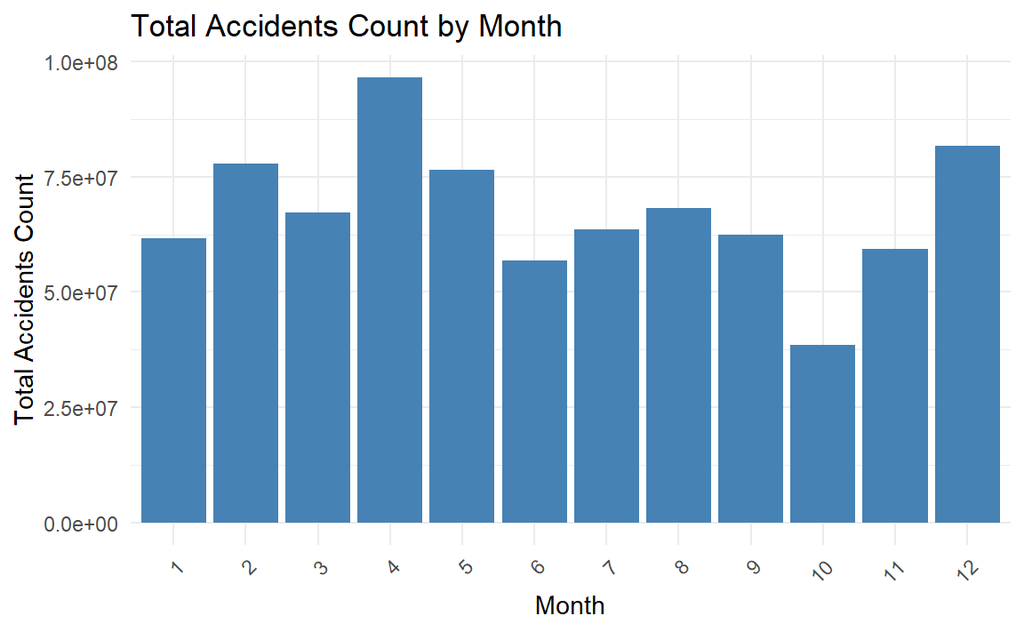

### Time interval

The time at which an accident occurs is a crucial factor in our analysis. We aim to investigate whether the timing of accidents significantly impacts the total number of accidents. By examining patterns related to the time of day, we seek to identify peak periods for accidents and understand how temporal factors contribute to accident frequency. This analysis will help us determine if specific times are associated with higher accident counts, providing valuable insights for improving traffic management and road safety interventions.

It is evident that the time when an accident occurs affects the accident count per state. we will therefore use this variable in our analysis.

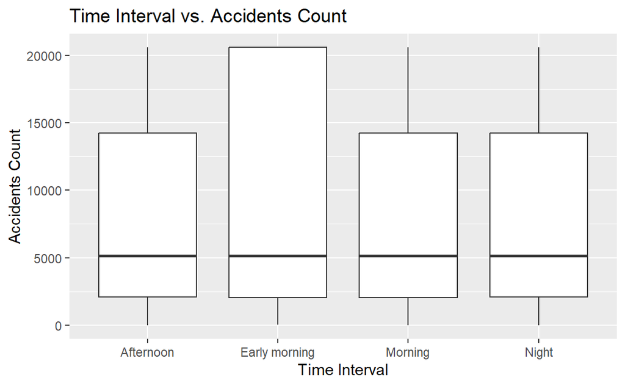

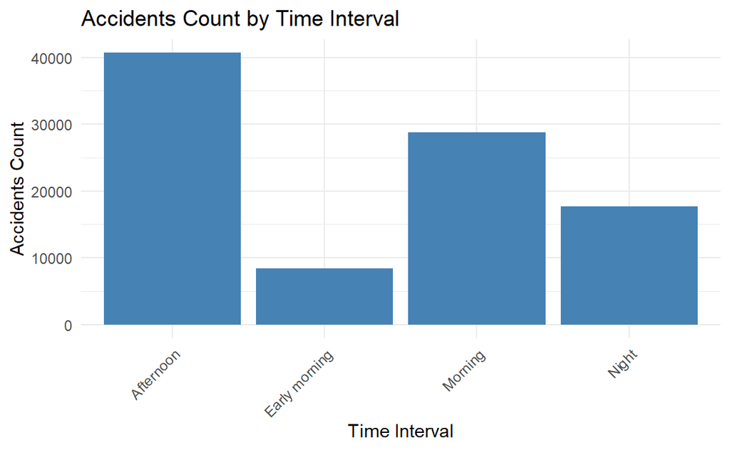

In conclusion we will use the following predictors for our poisson model. -severity -Weather conditions -month -time interval

### Poisson model fitting

```r
glm_accident_1 <- glm(accidents_count_per_state ~ severity + weather_cond + month + time_interval,
                 data = d.accidents,
                 family = poisson)
```

````
## ```
##
## Call:
## glm(formula = accidents_count_per_state ~ severity + weather_cond +
##     month + time_interval, family = poisson, data = d.accidents)
##
## Coefficients:
##                                           Estimate Std. Error  z value Pr(>|z|)
## (Intercept)                              6.506e+00  3.258e-02  199.673  < 2e-16
## severity2                                3.014e-01  2.889e-04 1043.351  < 2e-16
## severity3                                3.533e-02  3.410e-04  103.602  < 2e-16
## severity4                               -3.742e-01  4.222e-04 -886.164  < 2e-16
## weather_condBlowing Dust / Windy         2.134e+00  3.326e-02   64.167  < 2e-16
## weather_condBlowing Snow                 7.145e-01  3.303e-02   21.631  < 2e-16
## weather_condBlowing Snow / Windy         6.523e-01  3.282e-02   19.875  < 2e-16
## weather_condCloudy                       2.062e+00  3.258e-02   63.294  < 2e-16
## ...
## month12                                 ***
## time_intervalEarly morning              ***
## time_intervalMorning                    ***
## time_intervalNight                      ***
## ---
## Signif. codes:  0 '***' 0.001 '**' 0.01 '*' 0.05 '.' 0.1 ' ' 1
##
## (Dispersion parameter for poisson family taken to be 1)
##
##     Null deviance: 651469040  on 95620  degrees of freedom
## Residual deviance: 602625613  on 95537  degrees of freedom
## AIC: 603613620
##
## Number of Fisher Scoring iterations: 6
##
## ```
````

Upon examining the Poisson model, we observe that the residual deviance is 602,625,613 while the degrees of freedom are 95,537, indicating that our model is over-dispersed. In a well-fitting Poisson model, these two values would be approximately equal. To address this over-dispersion, we will construct a quasi-Poisson model to accurately account for the dispersion parameters and improve the model’s fit.

```r
quasi_accident_1 <- glm(accidents_count_per_state ~ severity + weather_cond + month + time_interval,
                 data = d.accidents,
                 family = quasipoisson)
```

````
## ```
##
## Call:
## glm(formula = accidents_count_per_state ~ severity + weather_cond +
##     month + time_interval, family = quasipoisson, data = d.accidents)
##
## Coefficients:
##                                          Estimate Std. Error t value Pr(>|t|)
## (Intercept)                              6.506026   2.574831   2.527 0.011513
## severity2                                0.301423   0.022830  13.203  < 2e-16
## severity3                                0.035328   0.026946   1.311 0.189846
## severity4                               -0.374177   0.033367 -11.214  < 2e-16
## weather_condBlowing Dust / Windy         2.134082   2.628142   0.812 0.416787
## weather_condBlowing Snow                 0.714519   2.610292   0.274 0.784292
## weather_condBlowing Snow / Windy         0.652283   2.593415   0.252 0.801417
## weather_condCloudy                       2.062267   2.574725   0.801 0.423153
## ...
## month12
## time_intervalEarly morning
## time_intervalMorning                    ***
## time_intervalNight                      .
## ---
## Signif. codes:  0 '***' 0.001 '**' 0.01 '*' 0.05 '.' 0.1 ' ' 1
##
## (Dispersion parameter for quasipoisson family taken to be 6244.576)
##
##     Null deviance: 651469040  on 95620  degrees of freedom
## Residual deviance: 602625613  on 95537  degrees of freedom
## AIC: NA
##
## Number of Fisher Scoring iterations: 6
##
## ```
````

From the quasi-Poisson model, we observe that the dispersion parameter is 6,244.576 compared to the fixed value of 1 in the Poisson model. This indicates that the variance increases faster than linearly.

### Interpreting some results

```r
## interpreting weather conditions
exp(coef(glm_accident_1)["weather_condDrizzle and Fog"])
```

```
## weather_condDrizzle and Fog
##                    2.450437
```

## Severity of Accidents

As much as the amount of accidents, the severity of the accidents are an important aspect to consider. Preventing serious accidents could prevent loss of life, serious injury as well as excessive material damage. It is therefore crucial to understand their causes.

## GLM -Binomial

The binomial model utilizes binary data for its analysis. To adapt our dataset for this model, we will convert the severity variable into a binary format. The original severity variable has four levels, ranging from one to four. We will combine levels 1 and 2 into a single category, labeled as 0, representing low severity. Similarly, we will merge levels 3 and 4 into another category, labeled as 1, representing high severity. This transformation will allow us to effectively apply the binomial model to our analysis.

```r
# Convert severity to binary
d.accidents_binary <- d.accidents %>%
  mutate(severity_binary = ifelse(severity %in% c(1, 2), 0, 1))
```

In this analysis, we are utilizing the boolean variables present in our dataset to gain deeper insights. These boolean variables, which represent binary states such as true/false or yes/no, will help us effectively categorize and analyze different aspects of the data. By leveraging these variables, we can streamline our analysis, enhance the accuracy of our models, and better understand the underlying patterns and trends in our dataset.

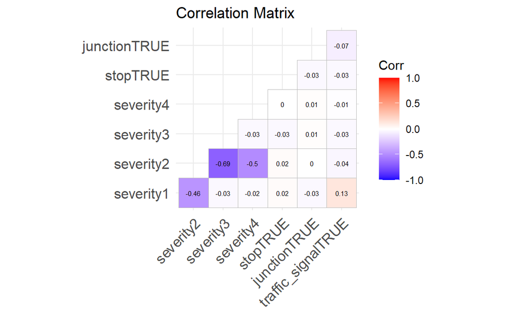

We are going to use the junction, stop and traffic_signal to build the glm binomial model since there seems to be some correlation between the severity and these variables. No obvious multicollinearity concerns can be observed.

```
##
## Call:
## glm(formula = severity_binary ~ junction + stop + traffic_signal,
##     family = binomial, data = d.accidents_binary)
##
## Coefficients:
##                    Estimate Std. Error  z value Pr(>|z|)
## (Intercept)        -2.54161    0.01371 -185.391  < 2e-16 ***
## junctionTRUE        0.15128    0.04799    3.152  0.00162 **
## stopTRUE           -1.08414    0.12541   -8.645  < 2e-16 ***
## traffic_signalTRUE -0.54911    0.05499   -9.985  < 2e-16 ***
## ---
## Signif. codes:  0 '***' 0.001 '**' 0.01 '*' 0.05 '.' 0.1 ' ' 1
##
## (Dispersion parameter for binomial family taken to be 1)
##
##     Null deviance: 48416  on 95620  degrees of freedom
## Residual deviance: 48183  on 95617  degrees of freedom
## AIC: 48191
##
## Number of Fisher Scoring iterations: 6
```

```r
exp(coef(glm_binomial_1)["junctionTRUE"])
```

```
## junctionTRUE
##      1.16332
```

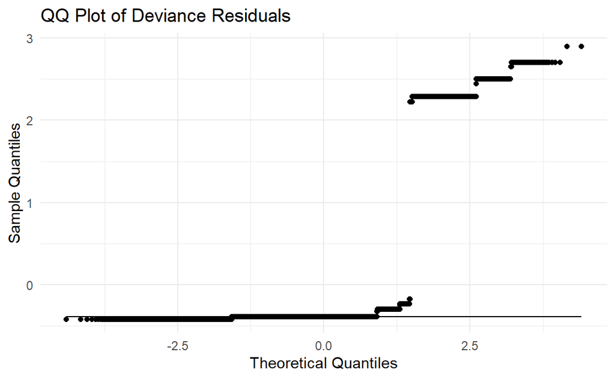

From this analysis we can see that the severity of accidents increases at junctions.This plot shows that this model does not fit our data.

## Support Vector Machine

#### Vitalia Vedenikova and Perez Olusese worked on this model

Now that we examined severity with a binomial model, we would like to increase the amount of predictors we use and check how accurately we can predict the severity of an accident. Support Vector Machines are particularly well adapted to the task as they are robust models capable of classifying accidents into various categories. In order to perfect our work, we will also supplement this method with cross validation techniques.

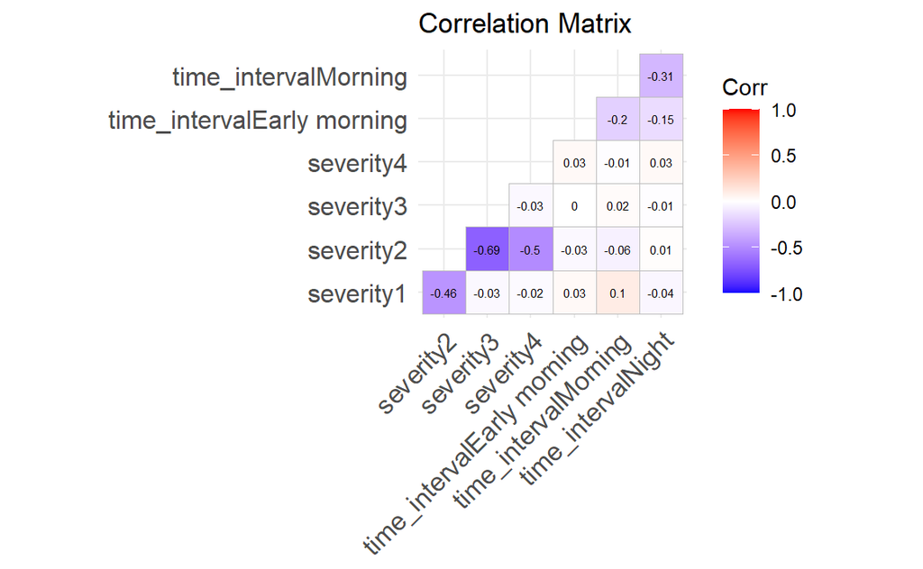

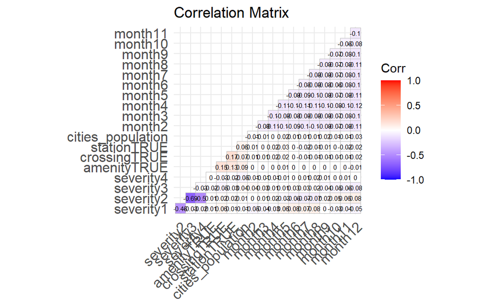

As a first step, we look at the types of predictors we could use with the help of two correlation matrices. What observe some level of collinearity with traffic sign variables, time intervals, months and cities populations. No obvious multicollinearity concerns can be observed. Street types are also chosen as a predictor since serious accidents often occur on high speed roads.

Our next step is to balance our data set. Indeed, there 13 times more accidents of a low severity than of a high one.

```
##
##     0     1
## 88945  6676
```

We therefore balance these two groups’ counts via stratified sampling to obtain equal proportions of minor and major accidents. If the count sizes are not equal, then the model’s true positive and true negative rates can be significantly reduced and lead to faulty classifications. The resulting sampled data is as follows:

```
##
##    0    1
## 6676 6676
```

### Initial SVM model fitting

```r
# Convert boolean columns to factors
d.accidents_vector[, (bool_cols) := lapply(.SD, as.factor), .SDcols = bool_cols]

# Define the target variable and features
y <- d.accidents_vector$severity
X <- d.accidents_vector[, !("severity"), with = FALSE]

# Split the data into training and testing sets
set.seed(123) # For reproducibility
trainIndex <- createDataPartition(y, p = 0.8, list = FALSE, times = 1)
X_train <- X[trainIndex,]
X_test <- X[-trainIndex,]
y_train <- y[trainIndex]
y_test <- y[-trainIndex]

# Set seed for reproducibility
set.seed(123)

# Train the SVM model with the RBF kernel-linear and cost set to 10
svm_model <- svm(
  as.factor(y_train) ~ .,
  data = X_train,
  kernel = "linear",
  cost = 10,
)
```

### Predicting the test set and evaluating the model:

```r
##### Make predictions on the test set #####
predictions <- predict(svm_model, X_test)

##### Evaluate the model #####
conf_matrix <- confusionMatrix(predictions, as.factor(y_test))
print(conf_matrix)
```

```
## Confusion Matrix and Statistics
##
##           Reference
## Prediction   0   1
##          0 855 363
##          1 480 972
##
##                Accuracy : 0.6843
##                  95% CI : (0.6663, 0.7019)
##     No Information Rate : 0.5
##     P-Value [Acc > NIR] : < 2.2e-16
##
##                   Kappa : 0.3685
##
##  Mcnemar's Test P-Value : 6.463e-05
##
##             Sensitivity : 0.6404
##             Specificity : 0.7281
##          Pos Pred Value : 0.7020
##          Neg Pred Value : 0.6694
##              Prevalence : 0.5000
##          Detection Rate : 0.3202
##    Detection Prevalence : 0.4562
##       Balanced Accuracy : 0.6843
##
##        'Positive' Class : 0
##
```

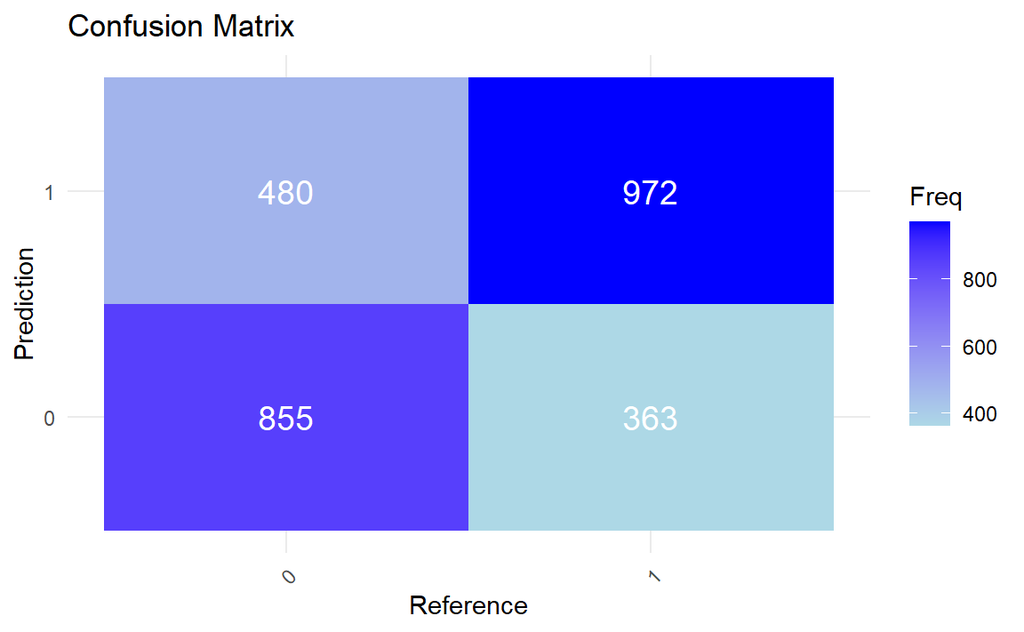

```r
##### Defining the Confusion matrix #####
# Convert confusion matrix to a data frame for ggplot2
conf_df <- as.data.frame(conf_matrix$table)
colnames(conf_df) <- c("Prediction", "Reference", "Freq")
```

At this stage, the accuracy of our model is of 68%. It has a sensitivity that is at 64%. It means that it is quite accurate in dividing serious and minor accidents. The specificity, which refers to the true negative rate, is somewhat high at 73%. The Pos Pred Value, which refers to the precision is acceptable at 70%, meaning that there is a high proportion of predicted positive cases that are correctly identified. There is a lower proportion of negative cases that are correctly identified at 67%. Overall, we may say that our model is rather consistent with most indicators being between 64% and 73% but not very accurate in its predictions.

We try to fit a model with RBF kernel-radial to see if we could get better results. However, as the accuracy turns out to be slightly lower and the sensitivity 10% inferior, we discard this model.

```r
# Train the SVM model with the RBF kernel-radial and cost set to 100
svm_model <- svm(
  as.factor(y_train) ~ .,
  data = X_train,
  kernel = "radial",
  cost = 100,
)
```

```
##  Accuracy
## 0.6794007
```

```
## Sensitivity
##   0.5550562
```

```r
# Set seed for reproducibility
set.seed(123)

# Number of folds
k <- 5

# Create folds
folds <- createFolds(y, k = k, list = TRUE)

# Initialize a vector to store accuracy for each fold
accuracy <- numeric(k)

# Perform cross-validation
  for (i in 1:k) {
  # Split the data into training and testing sets
  train_indices <- folds[[i]]
  X_train <- X[-train_indices,]
  y_train <- y[-train_indices]
  X_test <- X[train_indices,]
  y_test <- y[train_indices]

  # Train the SVM model with linear kernel
  svm_model <- svm(as.factor(y_train) ~ ., data = X_train, kernel = "linear",
                   ranges = list(cost = c(0.001, 0.01, 0.1, 1, 5, 10, 100)))

  summary(svm_model)

  # Make predictions on the test set
  predictions <- predict(svm_model, X_test)
  table(predictions)

  # Calculate accuracy
  accuracy[i] <- mean(predictions == y_test)
}

# Print the average accuracy
max_accuracy <- max(accuracy)
print(max_accuracy)
```

```
## [1] 0.6827715
```

In conclusion, while our binomial model allowed us to understand the types of relations between the severity and some predictors, with out SVM model we tested out their predictive power with measures of accuracy, sensitivity and so on. Although our prediction model was not the best at around 68% adjusted accuracy, it still tells us that variables related to various traffic signs, the cities’ populations, street types and time intervals all have a somewhat strong impact on the severity of an accident.